# Targeting A Housing Subsidy - Marissa & Alyssa

2023-11-03

## Introduction

Within the Department of Housing and Community Development in Emil City, a home repair tax credit program is attempting to create a proactive approach to targeting homeowners who qualify. While this program has been around for twenty years, this department has only been met with low conversion rates due to the randomness of the outreach to eligible homeowners. In order to combat this randomness and create an intentional decision-making that increases outreach and uptake of the program, this model uses different factors/variables within a cost/benefit analysis in order to predict if a household will take the credit, allocating $2850 per homeowner for outreach.The credit then allocates $5,000 per homeowner to use for home repair.

```r
options(scipen=10000000)
```

```r
library(tidyverse)
library(caret)
library(knitr)
library(pscl)
library(plotROC)
library(pROC)
library(scales)
library(dplyr)
library(kableExtra)
library(ggplot2)
library(gridExtra)

root.dir = "https://raw.githubusercontent.com/urbanSpatial/Public-Policy-Analytics-Landing/master/DATA/"
source("https://raw.githubusercontent.com/urbanSpatial/Public-Policy-Analytics-Landing/master/functions.r")
```

```r
housingSubsidy <- read.csv("C:/Users/cruse/Downloads/housingSubsidy.csv")
housingSubsidy$y_factor <- as.factor(housingSubsidy$y_numeric)
```

## Variables Impacting Likelihood of Entering Program

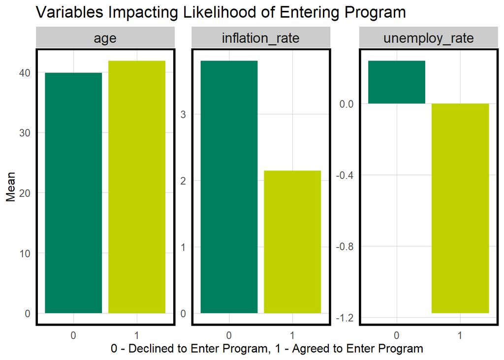

```r
housingSubsidy %>%
  dplyr::select(y_factor, unemploy_rate, inflation_rate, age) %>%
  gather(Variable, value, -y_factor) %>%
  ggplot(aes(x = y_factor, y = value, fill = y_factor)) +
  geom_bar(stat = "summary", fun = "mean", position = "dodge") +
  facet_wrap(~Variable, scales = "free") +
  labs(x = "0 - Declined to Enter Program, 1 - Agreed to Enter Program", y = "Mean",
       title = "Variables Impacting Likelihood of Entering Program ") +
  scale_fill_manual(values = c("#007f5f", "#bfd200")) +
  plotTheme() +
  theme(legend.position = "none")
```

## Engineering New Features

In utilizing the Housing Subsidy Dataset, that was previously collected, we engineered two new features. In order to understand the uptake of the home repair tax credit program, our team focused on creating different age groups, including: 18-25, 25-30, 30-40, 40-50, and 50 and up. In doing so, this allows us to understand which ages were more vital in targeting within outreach of the program. Additionally, this analysis aggregates 4 years of schooling, 6 years of schooling, and 9 years of school into one variable known as ‘lessthanHS’, to understand how levels of education, more specifically how having less than a high school diploma, play into uptake of the program, after outreach. In understanding this, this makes a clearer understanding of education attainment as we reduce variables

```r
housingSubsidy1 <- housingSubsidy
housingSubsidy1$education <- ifelse(housingSubsidy1$education %in% c("basic.4y", "basic.6y", "basic.9y"), "lessthanHS", housingSubsidy1$education)
```

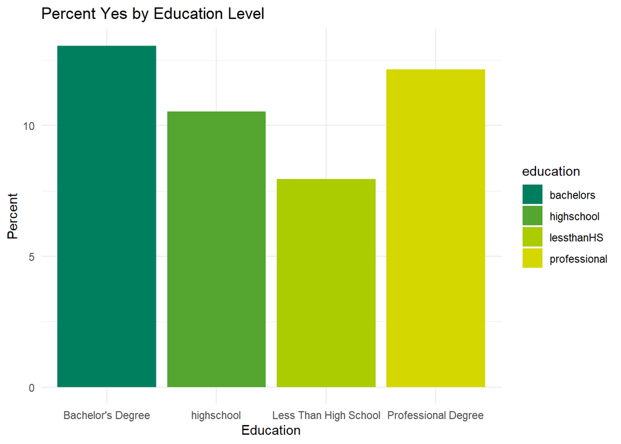

```r
bachelors_count <- housingSubsidy1 %>%
  filter(education == "university.degree") %>%
  nrow()

bachelors_yes <- housingSubsidy1 %>%
  filter(education == "university.degree" & y_numeric == 1) %>%
  nrow()
Bachelors_YesPerc <- bachelors_yes/bachelors_count*100

lessthanHS_count <- housingSubsidy1 %>%
  filter(education == "lessthanHS") %>%
  nrow()
lessthanHS_yes <- housingSubsidy1 %>%
  filter(education == "lessthanHS" & y_numeric == 1) %>%
  nrow()
lessthanHS_YesPerc <- lessthanHS_yes/lessthanHS_count*100

HS_count <- housingSubsidy1 %>%
  filter(education == "high.school") %>%
  nrow()
HS_yes <- housingSubsidy1 %>%
  filter(education == "high.school" & y_numeric == 1) %>%
  nrow()
HS_YesPerc <- HS_yes/HS_count*100

prof_count <- housingSubsidy1 %>%
  filter(education == "professional.course") %>%
  nrow()
prof_yes <- housingSubsidy1 %>%
  filter(education == "professional.course" & y_numeric == 1) %>%
  nrow()
prof_YesPerc <- prof_yes/prof_count*100

edudata <- data.frame(
  education = c("bachelors", "professional", "highschool", "lessthanHS"),
  percent_yes = c(Bachelors_YesPerc, prof_YesPerc, HS_YesPerc, lessthanHS_YesPerc)
)

ggplot(edudata, aes(x = education, y = percent_yes, fill = education)) +
  geom_bar(stat = "identity") +
  scale_fill_manual(values = c("#007f5f", "#55a630", "#aacc00", "#d4d700")) +
  scale_x_discrete(labels = c(
    "highscool" = "High School",
    "lessthanHS" = "Less Than High School",
    "professional" = "Professional Degree",
    "bachelors"= "Bachelor's Degree")) +
  labs(title = "Percent Yes by Education Level", x = "Education", y = "Percent") +
  theme_minimal()
```

```r
housingSubsidy1 <- housingSubsidy1 %>%
  mutate(age1 = ifelse(age >= 18 & age <= 25, "18-25",
           ifelse(age > 25 & age <= 30, "25-30",
           ifelse(age > 30 & age <= 40, "30-40",
           ifelse(age > 40 & age <= 50, "40-50", "50 and up")))))
```

## Creating a Train and Test Set for Our Models

```r
set.seed(3456)
trainIndex <- createDataPartition(housingSubsidy$y_numeric, p = .65, list = FALSE, times = 1)
train_set <- housingSubsidy[ trainIndex,]
test_set  <- housingSubsidy[-trainIndex,]
reg1 <- glm(y_numeric ~ .,
                  data=housingSubsidy %>% dplyr::select(-y_factor,
                                                    -y),
                  family="binomial" (link="logit"))

summary(reg1)
```

```
##
## Call:
## glm(formula = y_numeric ~ ., family = binomial(link = "logit"),
##     data = housingSubsidy %>% dplyr::select(-y_factor, -y))
##
## Coefficients:
##                                    Estimate     Std. Error z value  Pr(>|z|)
## (Intercept)                  -180.616801010  105.151758799  -1.718   0.08586
## X                              -0.000008325    0.000048654  -0.171   0.86414
## age                             0.016040853    0.006871604   2.334   0.01958
## jobblue-collar                 -0.316342962    0.225711655  -1.402   0.16105
## jobentrepreneur                -0.548802536    0.398890802  -1.376   0.16888
## jobhousemaid                   -0.187627201    0.397968667  -0.471   0.63731
## jobmanagement                  -0.481014719    0.249961846  -1.924   0.05431
## jobretired                     -0.287000339    0.303724726  -0.945   0.34469
## jobself-employed               -0.583226518    0.346802133  -1.682   0.09262
## jobservices                    -0.201702330    0.239102466  -0.844   0.39890
## jobstudent                     -0.021016271    0.350334771  -0.060   0.95216
## jobtechnician                  -0.042931110    0.192035729  -0.224   0.82310
## jobunemployed                   0.088858636    0.334598558   0.266   0.79057
## jobunknown                     -0.518287804    0.640276975  -0.809   0.41824
## maritalmarried                  0.174347909    0.201778144   0.864   0.38756
## maritalsingle                   0.284144959    0.231024951   1.230   0.21872
## maritalunknown                  0.077999226    1.183773510   0.066   0.94747
## educationbasic.6y               0.242137847    0.340536105   0.711   0.47705
## educationbasic.9y               0.132796723    0.272688586   0.487   0.62627
## educationhigh.school            0.117478321    0.261922276   0.449   0.65378
## educationilliterate           -11.958940750  535.411372688  -0.022   0.98218
## educationprofessional.course    0.213357578    0.284742084   0.749   0.45368
## educationuniversity.degree      0.193230645    0.263062066   0.735   0.46262
## educationunknown                0.191631684    0.345280758   0.555   0.57889
## taxLienunknown                 -0.024996946    0.177907948  -0.141   0.88826
## taxLienyes                    -10.296012284  535.411363785  -0.019   0.98466
## mortgageunknown                -0.272204567    0.445683801  -0.611   0.54136
## mortgageyes                    -0.101296541    0.117326198  -0.863   0.38793
## taxbill_in_phlyes               0.075090256    0.159297214   0.471   0.63737
## contacttelephone               -1.028094664    0.236516032  -4.347 0.0000138
## monthaug                       -0.026116323    0.357811511  -0.073   0.94181
## monthdec                        0.879594336    0.584381727   1.505   0.13228
## monthjul                       -0.090472987    0.300947392  -0.301   0.76370
```

[output cut: 69 more lines]

```
## unemploy_rate                **
## cons.price.idx               *
## cons.conf.idx                *
## inflation_rate
## spent_on_repairs
## ---
## Signif. codes:  0 '***' 0.001 '**' 0.01 '*' 0.05 '.' 0.1 ' ' 1
##
## (Dispersion parameter for binomial family taken to be 1)
##
##     Null deviance: 2845.8  on 4118  degrees of freedom
## Residual deviance: 2205.3  on 4066  degrees of freedom
## AIC: 2311.3
##
## Number of Fisher Scoring iterations: 12
```

```r
testoutcomes <- data.frame((Outcome = test_set$y_factor),
                        Probability = predict(reg1, test_set, type= "response"))
head(testoutcomes)
```

```
##    X.Outcome...test_set.y_factor. Probability
## 5                               0  0.07318376
## 9                               0  0.02838294
## 10                              0  0.03222781
## 13                              0  0.04787940
## 15                              0  0.11705509
## 19                              0  0.03066495
```

```r
testoutcomes <-
  testoutcomes %>%
  mutate(predOutcome  = as.factor(ifelse(testoutcomes$Probability > 0.5 , 1, 0)))

head(testoutcomes)
```

```
##    X.Outcome...test_set.y_factor. Probability predOutcome
## 5                               0  0.07318376           0
## 9                               0  0.02838294           0
## 10                              0  0.03222781           0
## 13                              0  0.04787940           0
## 15                              0  0.11705509           0
## 19                              0  0.03066495           0
```

```r
caret::confusionMatrix(testoutcomes$predOutcome, testoutcomes$X.Outcome...test_set.y_factor., positive = "1")
```

```
## Confusion Matrix and Statistics
##
##           Reference
## Prediction    0    1
##          0 1273  115
##          1   22   31
##
##                Accuracy : 0.9049
##                  95% CI : (0.8886, 0.9196)
##     No Information Rate : 0.8987
##     P-Value [Acc > NIR] : 0.2306
##
##                   Kappa : 0.2723
##
##  Mcnemar's Test P-Value : 0.000000000000003839
##
##             Sensitivity : 0.21233
##             Specificity : 0.98301
##          Pos Pred Value : 0.58491
##          Neg Pred Value : 0.91715
##              Prevalence : 0.10132
##          Detection Rate : 0.02151
##    Detection Prevalence : 0.03678
##       Balanced Accuracy : 0.59767
##
##        'Positive' Class : 1
##
```

```r
reg2 <- glm(y_numeric ~ .,
                  data=housingSubsidy1 %>% dplyr::select(-y_factor,
                                                    -y),
                  family="binomial" (link="logit"))

summary(reg2)
```

```
##
## Call:
## glm(formula = y_numeric ~ ., family = binomial(link = "logit"),
##     data = housingSubsidy1 %>% dplyr::select(-y_factor, -y))
##
## Coefficients:
##                                   Estimate    Std. Error z value  Pr(>|z|)
## (Intercept)                  -180.90125439  105.19986119  -1.720   0.08551 .
## X                              -0.00001100    0.00004866  -0.226   0.82121
## age                             0.01269487    0.01559135   0.814   0.41552
## jobblue-collar                 -0.30300363    0.22591793  -1.341   0.17985
## jobentrepreneur                -0.54946954    0.39930117  -1.376   0.16880
## jobhousemaid                   -0.20770008    0.39532677  -0.525   0.59931
## jobmanagement                  -0.48009451    0.25002658  -1.920   0.05484 .
## jobretired                     -0.28493102    0.32149408  -0.886   0.37547
## jobself-employed               -0.58301381    0.34742655  -1.678   0.09333 .
## jobservices                    -0.19693052    0.23931913  -0.823   0.41058
## jobstudent                      0.07894513    0.36955369   0.214   0.83084
## jobtechnician                  -0.04175514    0.19227316  -0.217   0.82808
## jobunemployed                   0.07475597    0.33521754   0.223   0.82353
## jobunknown                     -0.48101152    0.63691610  -0.755   0.45012
## maritalmarried                  0.16762039    0.20199902   0.830   0.40665
## maritalsingle                   0.27892765    0.23198639   1.202   0.22923
## maritalunknown                  0.03862959    1.18042002   0.033   0.97389
## educationilliterate           -12.07017103  535.41139200  -0.023   0.98201
## educationlessthanHS            -0.01700732    0.19721028  -0.086   0.93128
## educationprofessional.course    0.09239255    0.21947971   0.421   0.67378
## educationuniversity.degree      0.06923784    0.17158930   0.404   0.68657
## educationunknown                0.07763694    0.29733023   0.261   0.79400
## taxLienunknown                 -0.03136155    0.17761968  -0.177   0.85985
## taxLienyes                    -10.30667145  535.41136829  -0.019   0.98464
## mortgageunknown                -0.26981774    0.44570639  -0.605   0.54493
## mortgageyes                    -0.09910996    0.11732998  -0.845   0.39827
## taxbill_in_phlyes               0.06979646    0.15914723   0.439   0.66098
## contacttelephone               -1.02649074    0.23657921  -4.339 0.0000143 ***
## monthaug                       -0.03317963    0.35894131  -0.092   0.92635
## monthdec                        0.86064041    0.58411788   1.473   0.14064
## monthjul                       -0.08578305    0.30193840  -0.284   0.77633
## monthjun                       -0.03327803    0.37104428  -0.090   0.92854
## monthmar                        1.83006454    0.45256431   4.044 0.0000526 ***
```

[output cut: 17 more lines]

```
## spent_on_repairs                0.00433535    0.00851273   0.509   0.61056
## age125-30                       0.33068811    0.33880055   0.976   0.32904
## age130-40                       0.32386332    0.36879431   0.878   0.37985
## age140-50                       0.32027767    0.47231029   0.678   0.49770
## age150 and up                   0.36995694    0.60282149   0.614   0.53941
## ---
## Signif. codes:  0 '***' 0.001 '**' 0.01 '*' 0.05 '.' 0.1 ' ' 1
##
## (Dispersion parameter for binomial family taken to be 1)
##
##     Null deviance: 2845.8  on 4118  degrees of freedom
## Residual deviance: 2204.8  on 4064  degrees of freedom
## AIC: 2314.8
##
## Number of Fisher Scoring iterations: 12
```

```r
train_set1 <- housingSubsidy1[ trainIndex,]
test_set1  <- housingSubsidy1[-trainIndex,]
testoutcomes1 <- data.frame((Outcome = test_set1$y_factor),
                        Probability = predict(reg2, test_set1, type= "response"))
testoutcomes1 <-
  testoutcomes1 %>%
  mutate(predOutcome  = as.factor(ifelse(testoutcomes1$Probability > 0.5 , 1, 0)))

head(testoutcomes1)
```

```
##    X.Outcome...test_set1.y_factor. Probability predOutcome
## 5                                0  0.07139262           0
## 9                                0  0.02957148           0
## 10                               0  0.03210645           0
## 13                               0  0.04873121           0
## 15                               0  0.12236321           0
## 19                               0  0.02988307           0
```

```r
caret::confusionMatrix(testoutcomes1$predOutcome, testoutcomes1$X.Outcome...test_set1.y_factor., positive = "1")
```

```
## Confusion Matrix and Statistics
##
##           Reference
## Prediction    0    1
##          0 1273  114
##          1   22   32
##
##                Accuracy : 0.9056
##                  95% CI : (0.8893, 0.9202)
##     No Information Rate : 0.8987
##     P-Value [Acc > NIR] : 0.2045
##
##                   Kappa : 0.2806
##
##  Mcnemar's Test P-Value : 0.000000000000006036
##
##             Sensitivity : 0.21918
##             Specificity : 0.98301
##          Pos Pred Value : 0.59259
##          Neg Pred Value : 0.91781
##              Prevalence : 0.10132
##          Detection Rate : 0.02221
##    Detection Prevalence : 0.03747
##       Balanced Accuracy : 0.60109
##
##        'Positive' Class : 1
##
```

## ROC and Area Under Curves

The ROC Curve for both of our models using indicates that our models’ variables are a useful fit in deciding where to allocate marketing resources. The y=x line indicates that any true positive rate has a corresponding false positive rate. An ROC Curve above the y=x line indicates that for every false positive rates, there is a higher number of true positives. Additionally, the AUC for the first model using non engineered variables was 0.8068, while the AUC for the second model using engineered variables was 0.8086. This increase in the area under the curve indicates that the model using engineered variables indicates a slightly more useful fit.

```r
auc(testoutcomes$X.Outcome...test_set.y_factor., testoutcomes$Probability)
```

```
## Area under the curve: 0.8068
```

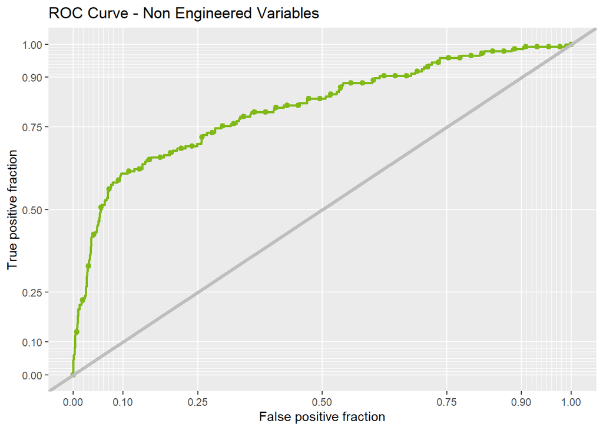

```r
ggplot(testoutcomes, aes(d = as.numeric(X.Outcome...test_set.y_factor.), m = Probability)) +
  geom_roc(n.cuts = 50, labels = FALSE, colour = "#80b918") +
  style_roc(theme = theme_grey) +
  geom_abline(slope = 1, intercept = 0, size = 1.5, color = 'grey') +
  labs(title = "ROC Curve - Non Engineered Variables")
```

```r
auc(testoutcomes1$X.Outcome...test_set1.y_factor., testoutcomes1$Probability)
```

```
## Area under the curve: 0.8086
```

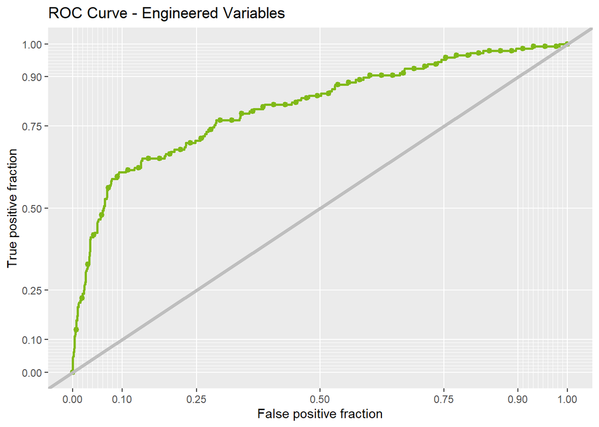

```r
ggplot(testoutcomes1, aes(d = as.numeric(X.Outcome...test_set1.y_factor.), m = Probability)) +
  geom_roc(n.cuts = 50, labels = FALSE, colour = "#80b918") +
  style_roc(theme = theme_grey) +
  geom_abline(slope = 1, intercept = 0, size = 1.5, color = 'grey') +
  labs(title = "ROC Curve - Engineered Variables")
```

## Cross Validation Goodness of Fit Metrics

We then plotted our goodness of fit metrics(Area Under Curve, Sensitivity, and Specificity) for the first model, representing variables that were not engineered and further our second model, with engineered variables through running a 100-k folds cross-validation test. Within the figure, the distribution of the area under the ROC curve, the sensitivity, and specificity for each model are all represented. A more generalizable model is shown through a tighter distribution, showing a more clustered group of variables. The models generalize well for sensitivity, however lack generalizability for specificity. In using the engineered features for cross-validation, there was an increase in all three goodness of fit metrics.

```r
ctrl <- trainControl(method = "cv", number = 100, classProbs=TRUE, summaryFunction=twoClassSummary)

cvFit <- train(y ~ .,
                  data=housingSubsidy %>%
                    dplyr::select(-y_factor, -y_numeric),
                method="glm", family="binomial",
                metric="ROC", trControl = ctrl)

cvFit
```

```
## Generalized Linear Model
##
## 4119 samples
##   20 predictor
##    2 classes: 'no', 'yes'
##
## No pre-processing
## Resampling: Cross-Validated (100 fold)
## Summary of sample sizes: 4078, 4077, 4079, 4079, 4078, 4078, ...
## Resampling results:
##
##   ROC        Sens       Spec
##   0.7597541  0.9806607  0.21
```

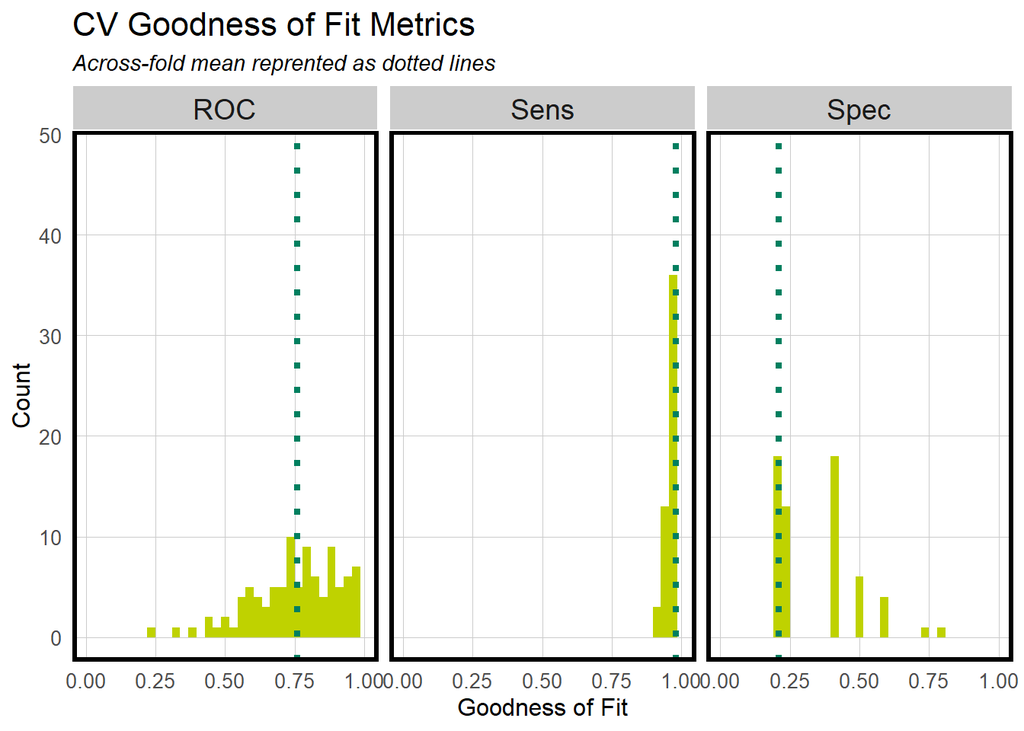

```r
dplyr::select(cvFit$resample, -Resample) %>%
  gather(metric, value) %>%
  left_join(gather(cvFit$results[2:4], metric, mean)) %>%
  ggplot(aes(value)) +
    geom_histogram(bins=35, fill = "#bfd200") +
    facet_wrap(~metric) +
    geom_vline(aes(xintercept = mean), colour = "#007f5f", linetype = 3, size = 1.5) +
    scale_x_continuous(limits = c(0, 1)) +
    labs(x="Goodness of Fit", y="Count", title="CV Goodness of Fit Metrics",
         subtitle = "Across-fold mean reprented as dotted lines") +
    plotTheme()
```

```r
cvFit1 <- train(y ~ .,
                  data=housingSubsidy1 %>%
                    dplyr::select(-y_factor, -y_numeric),
                method="glm", family="binomial",
                metric="ROC", trControl = ctrl)

cvFit1
```

```
## Generalized Linear Model
##
## 4119 samples
##   21 predictor
##    2 classes: 'no', 'yes'
##
## No pre-processing
## Resampling: Cross-Validated (100 fold)
## Summary of sample sizes: 4077, 4079, 4078, 4077, 4078, 4078, ...
## Resampling results:
##
##   ROC       Sens       Spec
##   0.765908  0.9809384  0.2185
```

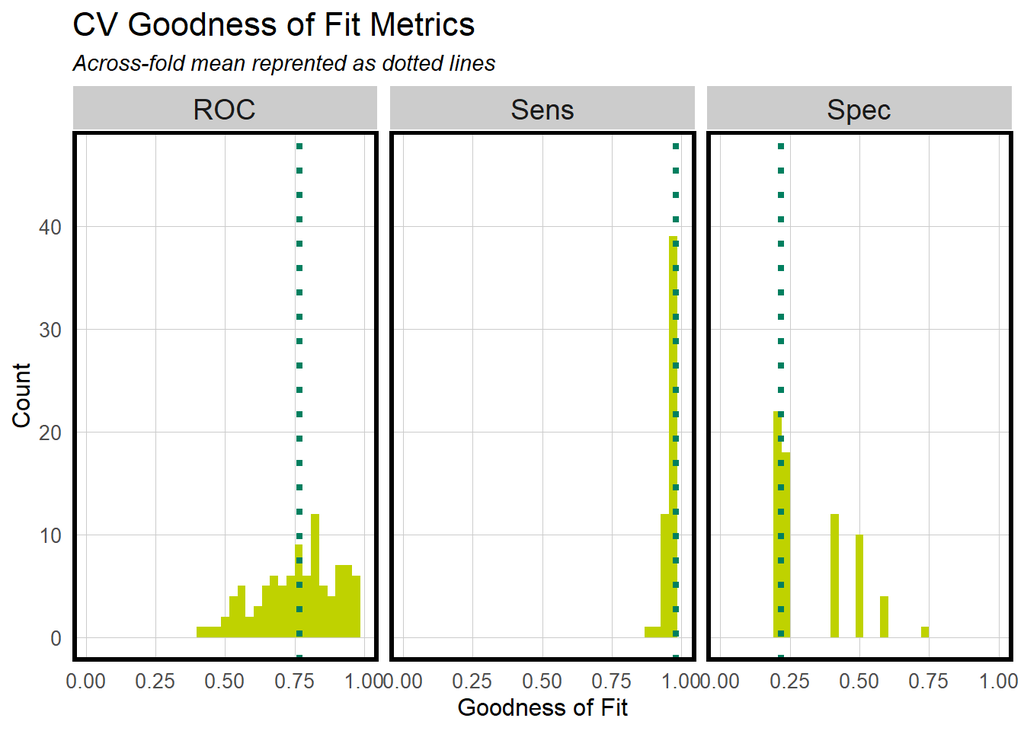

```r
dplyr::select(cvFit1$resample, -Resample) %>%
  gather(metric, value) %>%
  left_join(gather(cvFit1$results[2:4], metric, mean)) %>%
  ggplot(aes(value)) +
    geom_histogram(bins=35, fill = "#bfd200") +
    facet_wrap(~metric) +
    geom_vline(aes(xintercept = mean), colour = "#007f5f", linetype = 3, size = 1.5) +
    scale_x_continuous(limits = c(0, 1)) +
    labs(x="Goodness of Fit", y="Count", title="CV Goodness of Fit Metrics",
         subtitle = "Across-fold mean reprented as dotted lines") +
    plotTheme()
```

## Cost Benefit Analysis

For a true positive, our cost benefit equation = [(sum of benefit) - (costs)] x (count of true positive x 0.25). Multiplying the count of true positives by .25 occurs as only 25% of those will receive the credit.

For a true negative, our cost benefit equation = Count x 0, because no marketing resources were allocated to these cases.

For a false positive, our cost benefit equation = (cost of marketing allocation) x Count, because although we allocated the resources, this population did not receive the benefits.

```r
cost_benefit_table <-
   testoutcomes %>%
      count(predOutcome, X.Outcome...test_set.y_factor.) %>%
      summarize(True_Negative = sum(n[predOutcome==0 & X.Outcome...test_set.y_factor.==0]),
                True_Positive = sum(n[predOutcome==1 & X.Outcome...test_set.y_factor.==1]),
                False_Negative = sum(n[predOutcome==0 & X.Outcome...test_set.y_factor.==1]),
                False_Positive = sum(n[predOutcome==1 & X.Outcome...test_set.y_factor.==0])) %>%
        gather(Variable, Count) %>%
  mutate(
    Revenue = ifelse(
      Variable == "True_Negative", Count * 0,
      ifelse(Variable == "True_Positive", (66000 - 7850) * (0.25) * Count,
      ifelse(Variable == "False_Negative", (-66000 - 7850) * (0.25) * Count,
      ifelse(Variable == "False_Positive", (-2850) * Count, 0))))) %>%
    bind_cols(data.frame(Description = c(
              "We correctly predicted participant declining a housing subsidy",
              "We correctly predicted accepting a housing subsidy",
              "We predicted declining the housing subsidy and participant accepted",
              "We predicted an acceptance of the housing subsidy and participant declined")))

kable(cost_benefit_table,
       caption = "Cost/Benefit Table") %>%
    kable_styling()
```

Cost/Benefit Table

| Variable | Count | Revenue | Description |
| --- | --- | --- | --- |
| True_Negative | 1273 | 0.0 | We correctly predicted participant declining a housing subsidy |
| True_Positive | 31 | 450662.5 | We correctly predicted accepting a housing subsidy |
| False_Negative | 115 | -2123187.5 | We predicted declining the housing subsidy and participant accepted |
| False_Positive | 22 | -62700.0 | We predicted an acceptance of the housing subsidy and participant declined |

```r
cost_benefit_table1 <-
   testoutcomes1 %>%
      count(predOutcome, X.Outcome...test_set1.y_factor.) %>%
      summarize(True_Negative = sum(n[predOutcome==0 & X.Outcome...test_set1.y_factor.==0]),
                True_Positive = sum(n[predOutcome==1 & X.Outcome...test_set1.y_factor.==1]),
                False_Negative = sum(n[predOutcome==0 & X.Outcome...test_set1.y_factor.==1]),
                False_Positive = sum(n[predOutcome==1 & X.Outcome...test_set1.y_factor.==0])) %>%
        gather(Variable, Count) %>%
  mutate(
    Revenue = ifelse(
      Variable == "True_Negative", Count * 0,
      ifelse(Variable == "True_Positive", (66000 - 7850) * (0.25) * Count,
      ifelse(Variable == "False_Negative", (-66000 - 7850) * (0.25) * Count,
      ifelse(Variable == "False_Positive", (-2850) * Count, 0))))) %>%
    bind_cols(data.frame(Description = c(
              "We correctly predicted participant declining a housing subsidy",
              "We correctly predicted accepting a housing subsidy",
              "We predicted declining the housing subsidy and participant accepted",
              "We predicted an acceptance of the housing subsidy and participant declined")))

kable(cost_benefit_table1,
       caption = "Cost/Benefit Table") %>% kable_styling()
```

Cost/Benefit Table

| Variable | Count | Revenue | Description |
| --- | --- | --- | --- |
| True_Negative | 1273 | 0 | We correctly predicted participant declining a housing subsidy |
| True_Positive | 32 | 465200 | We correctly predicted accepting a housing subsidy |
| False_Negative | 114 | -2104725 | We predicted declining the housing subsidy and participant accepted |
| False_Positive | 22 | -62700 | We predicted an acceptance of the housing subsidy and participant declined |

```r
iterateThresholds <- function(data) {
  x = .01
  allprediction <- data.frame()
  while (x <= 1) {

  thisprediction <-
      testoutcomes %>%
      mutate(predOutcome = ifelse(Probability > x, 1, 0)) %>%
      count(predOutcome, X.Outcome...test_set.y_factor.) %>%
      summarize(True_Negative = sum(n[predOutcome==0 & X.Outcome...test_set.y_factor.==0]),
                True_Positive = sum(n[predOutcome==1 & X.Outcome...test_set.y_factor.==1]),
                False_Negative = sum(n[predOutcome==0 & X.Outcome...test_set.y_factor.==1]),
                False_Positive = sum(n[predOutcome==1 & X.Outcome...test_set.y_factor.==0])) %>%
        gather(Variable, Count) %>%
     gather(Variable, Count) %>%
     mutate(Revenue = ifelse(
      Variable == "True_Negative", Count * 0,
      ifelse(Variable == "True_Positive", (66000 - 7850) * (0.25) * Count,
      ifelse(Variable == "False_Negative", (-66000 - 7850) * (0.25) * Count,
      ifelse(Variable == "False_Positive", (-2850) * Count, 0)))),
            Threshold = x)

  allprediction <- rbind(allprediction, thisprediction)
  x <- x + .01
  }
return(allprediction)
}
```

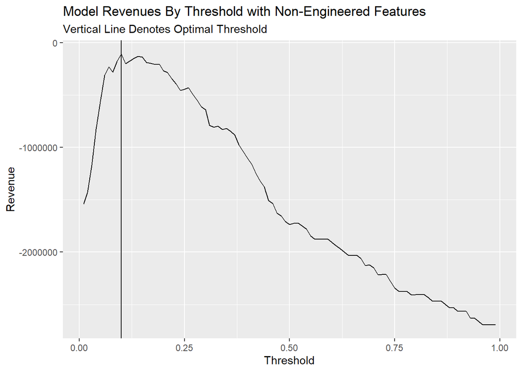

```r
whichThreshold <- iterateThresholds(testoutcomes)

whichThreshold_revenue <-
whichThreshold %>%
    group_by(Threshold) %>%
    summarize(Revenue = sum(Revenue))

  ggplot(whichThreshold_revenue)+
  geom_line(aes(x = Threshold, y = Revenue))+
  geom_vline(xintercept =  pull(arrange(whichThreshold_revenue, -Revenue)[1,1]))+
    labs(title = "Model Revenues By Threshold with Non-Engineered Features",
         subtitle = "Vertical Line Denotes Optimal Threshold")
```

```r
iterateThresholds1 <- function(data) {
  x = .01
  allprediction1 <- data.frame()
  while (x <= 1) {

  thisprediction1 <-
      testoutcomes1 %>%
      mutate(predOutcome = ifelse(Probability > x, 1, 0)) %>%
      count(predOutcome, X.Outcome...test_set1.y_factor.) %>%
      summarize(True_Negative = sum(n[predOutcome==0 & X.Outcome...test_set1.y_factor.==0]),
                True_Positive = sum(n[predOutcome==1 & X.Outcome...test_set1.y_factor.==1]),
                False_Negative = sum(n[predOutcome==0 & X.Outcome...test_set1.y_factor.==1]),
                False_Positive = sum(n[predOutcome==1 & X.Outcome...test_set1.y_factor.==0])) %>%
        gather(Variable, Count) %>%
     gather(Variable, Count) %>%
     mutate(Revenue = ifelse(
      Variable == "True_Negative", Count * 0,
      ifelse(Variable == "True_Positive", (66000 - 7850) * (0.25) * Count,
      ifelse(Variable == "False_Negative", (-66000 - 7850) * (0.25) * Count,
      ifelse(Variable == "False_Positive", (-2850) * Count, 0)))),
            Threshold = x)

  allprediction1 <- rbind(allprediction1, thisprediction1)
  x <- x + .01
  }
return(allprediction1)
}
```